# Comparison of Harbour Porpoise clicks

Lina Fliess

2024-06-24

## Comparison of median frequency of a whole train

## Hypothesis

H_0: There is no difference in the distribution of the median frequency (whole train) between the german and danish harbour porpoise clicks

## Exploratory Analysis

```r
summary(Ref_DE$medianKHz)
```

```
##    Min. 1st Qu.  Median    Mean 3rd Qu.    Max.
##    28.0   120.0   123.0   123.2   126.0   144.0
```

```r
summary(Ref_DK$medianKHz)
```

```
##    Min. 1st Qu.  Median    Mean 3rd Qu.    Max.
##      84     122     125     125     128     146
```

Visualization/Plots:

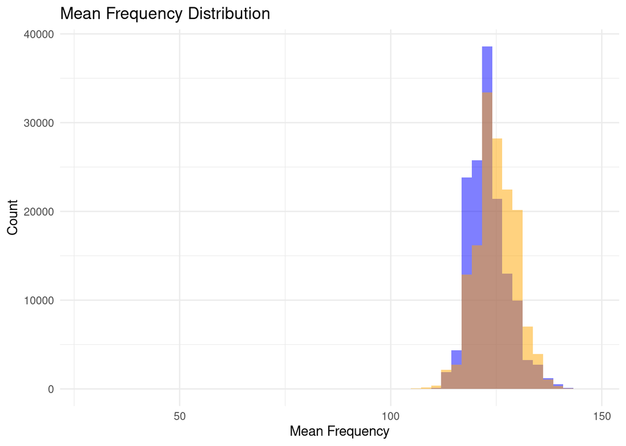

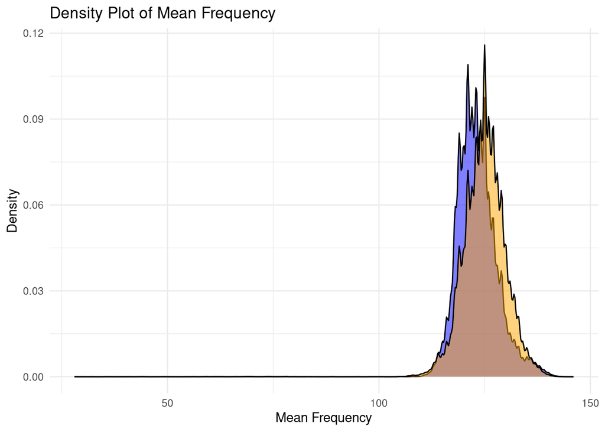

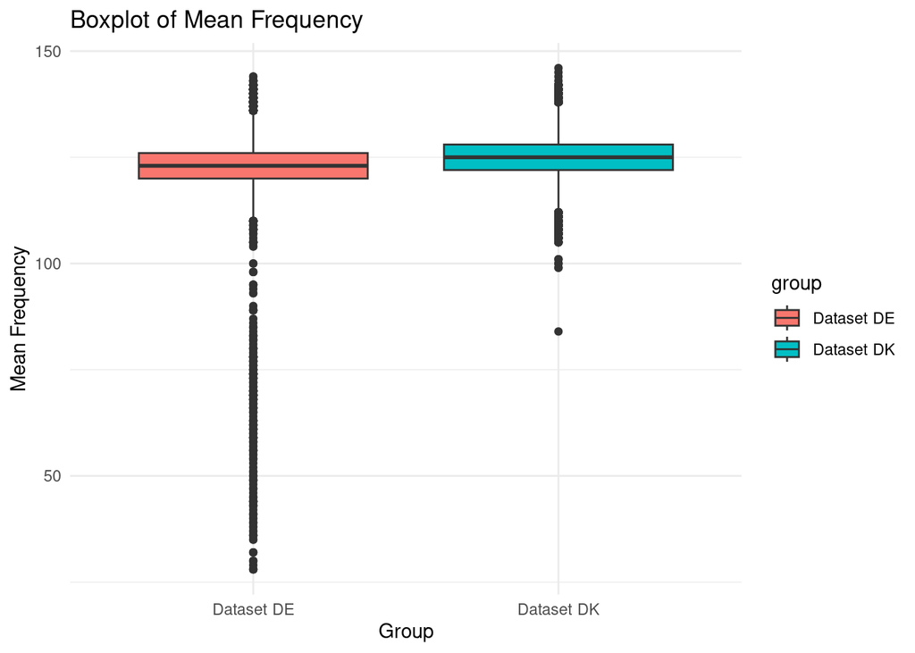

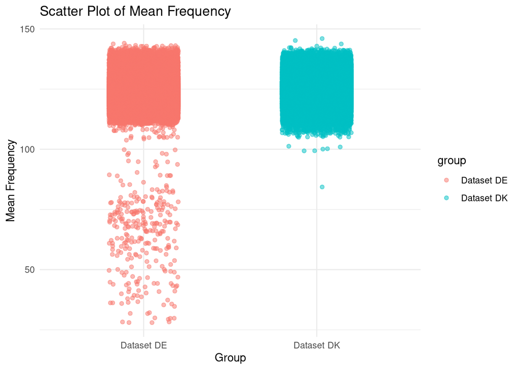

## Check Requirements for tests

### Normality of Distribution

- size of Dataframe too large for Shapiro-Wilk Test
- using Q-Q-Plots to get a visual idea and Kolmogorov-Smirnov Test as an alternative

Median Frequency DE:

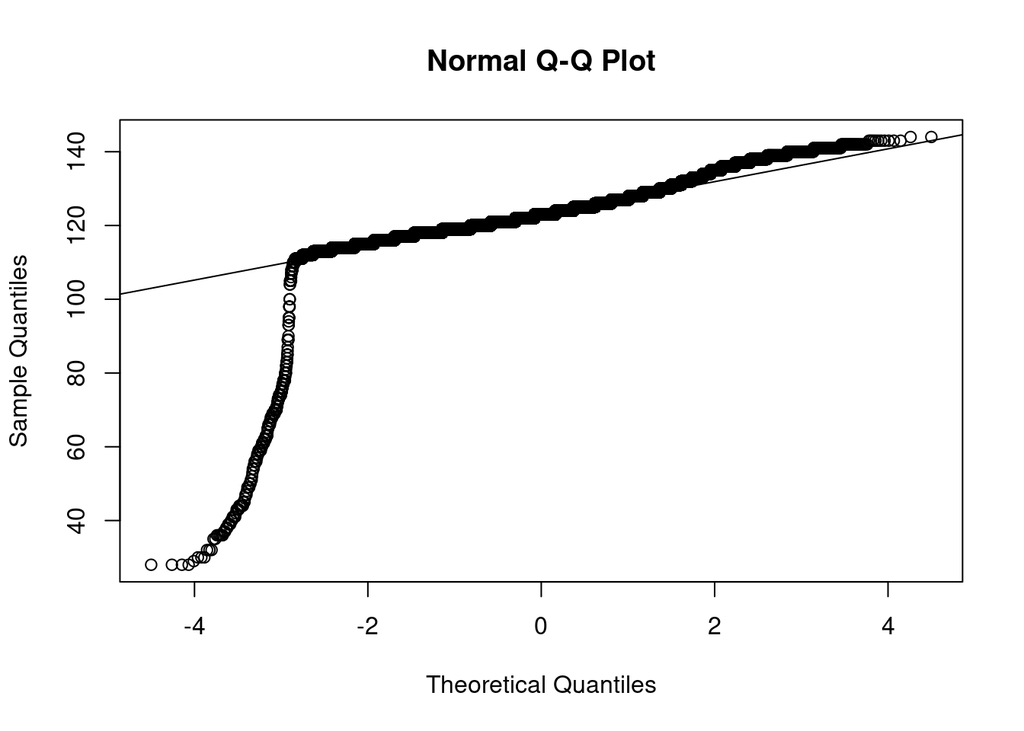

```
##
##  Asymptotic one-sample Kolmogorov-Smirnov test
##
## data:  Ref_DE$medianKHz
## D = 0.09672, p-value < 2.2e-16
## alternative hypothesis: two-sided
```

Median Frequency DK:

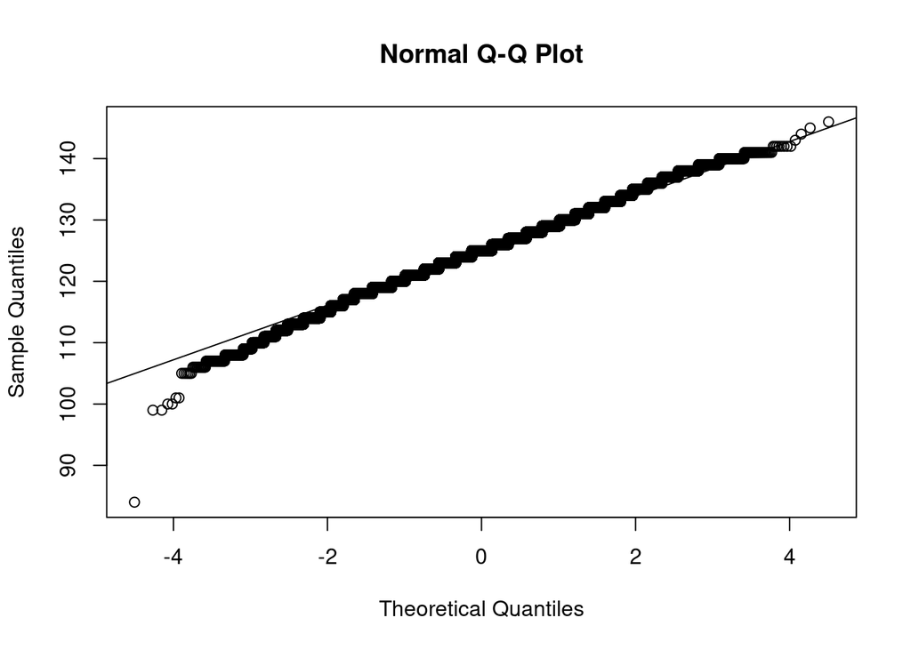

```
##
##  Asymptotic one-sample Kolmogorov-Smirnov test
##
## data:  Ref_DK$medianKHz
## D = 0.054253, p-value < 2.2e-16
## alternative hypothesis: two-sided
```

No noticeable normal distribution in Q-Q-Plot which is underlined by the result of the Kolmogorov-Smirnov-Test.  
The small p-value (<2.2e-16) suggest that the distribution significantly differs from normal distribution.

Also checking for homogeneity of variances (Levenes Test):

```
## Levene's Test for Homogeneity of Variance (center = median)
##           Df F value   Pr(>F)
## group      1  7.9812 0.004727 **
##       298231
## ---
## Signif. codes:  0 '***' 0.001 '**' 0.01 '*' 0.05 '.' 0.1 ' ' 1
```

p-value (0.004727) < 0.05  
–> statistically significant difference in variances between the groups  
Therefore the null hypothesis of homogeneity of variances is rejected.

## Statistical Test (Wilcoxon)

```
##
##  Wilcoxon rank sum test with continuity correction
##
## data:  Ref_DE$medianKHz and Ref_DK$medianKHz
## W = 8.457e+09, p-value < 2.2e-16
## alternative hypothesis: true location shift is not equal to 0
```

p (<2.2e-16) < 0.05  
–> there is a significant difference between the datasets for the criterion median frequency

## Comparison of average frequency of last Cycle

## Hypothesis

H_0: There is no difference in the distribution of the average frequency of the last cycle between the german and danish harbour porpoise clicks

## Exploratory Analysis

```r
summary(Ref_DE$avEndF)
```

```
##    Min. 1st Qu.  Median    Mean 3rd Qu.    Max.
##    26.0   122.0   126.0   125.7   129.0   168.0
```

```r
summary(Ref_DK$avEndF)
```

```
##    Min. 1st Qu.  Median    Mean 3rd Qu.    Max.
##    61.0   125.0   128.0   127.9   131.0   164.0
```

Visualization/Plots:

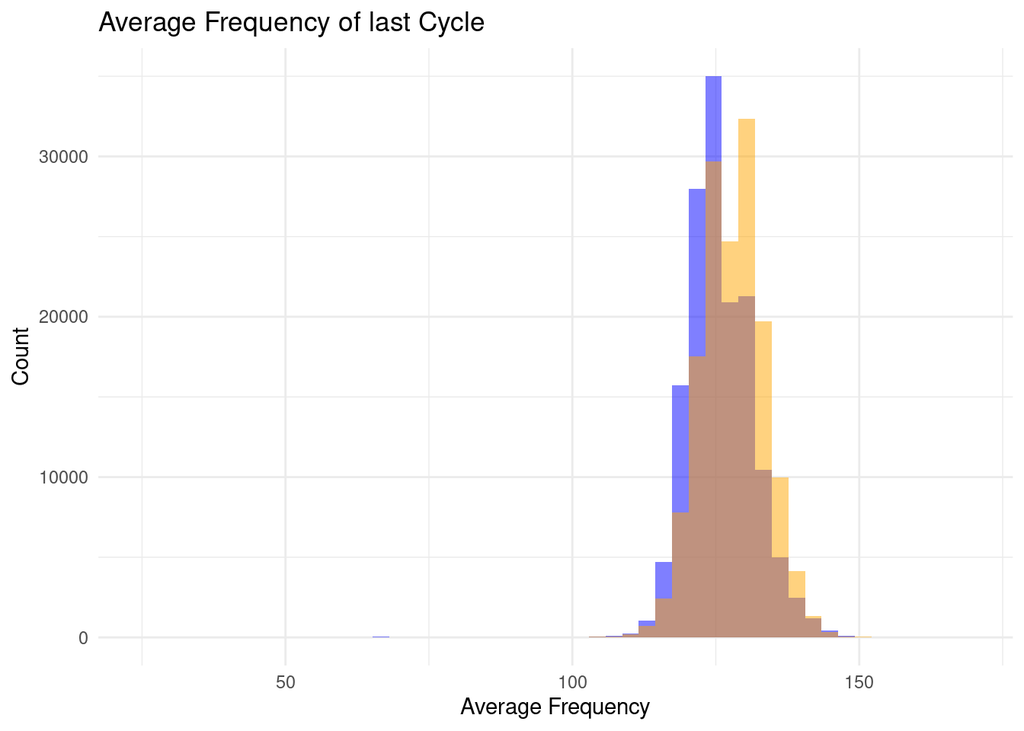

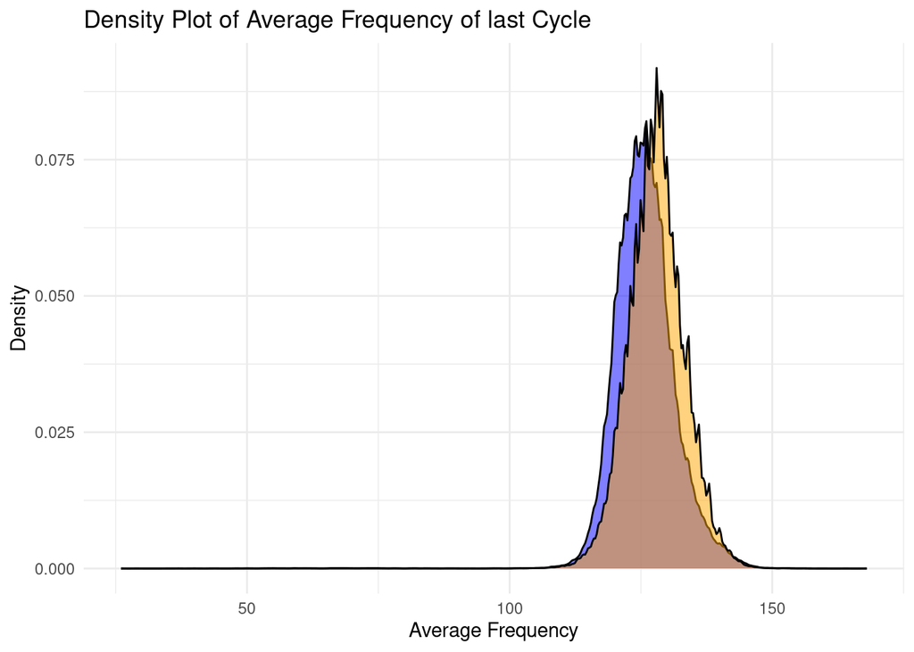

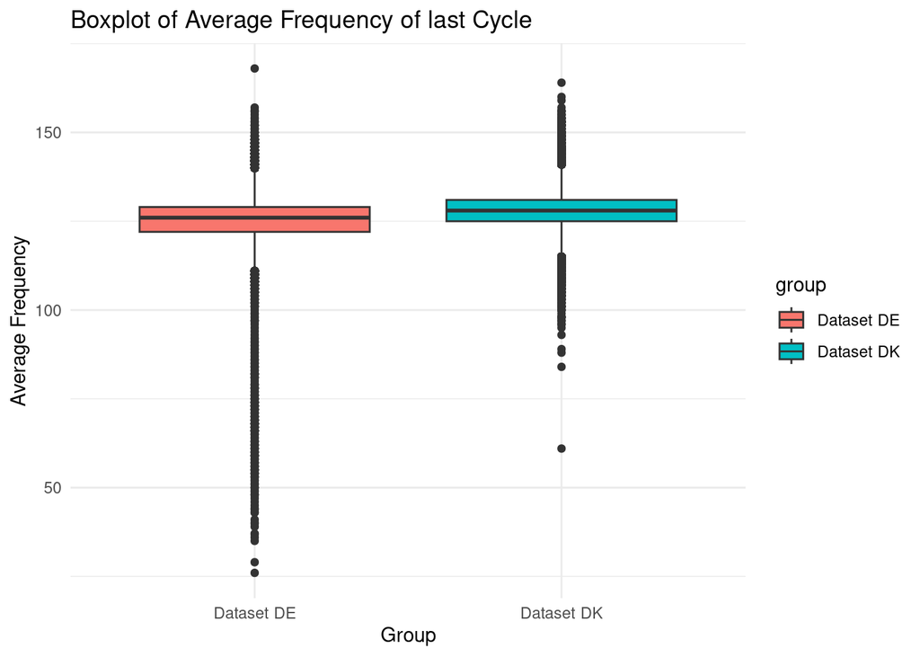

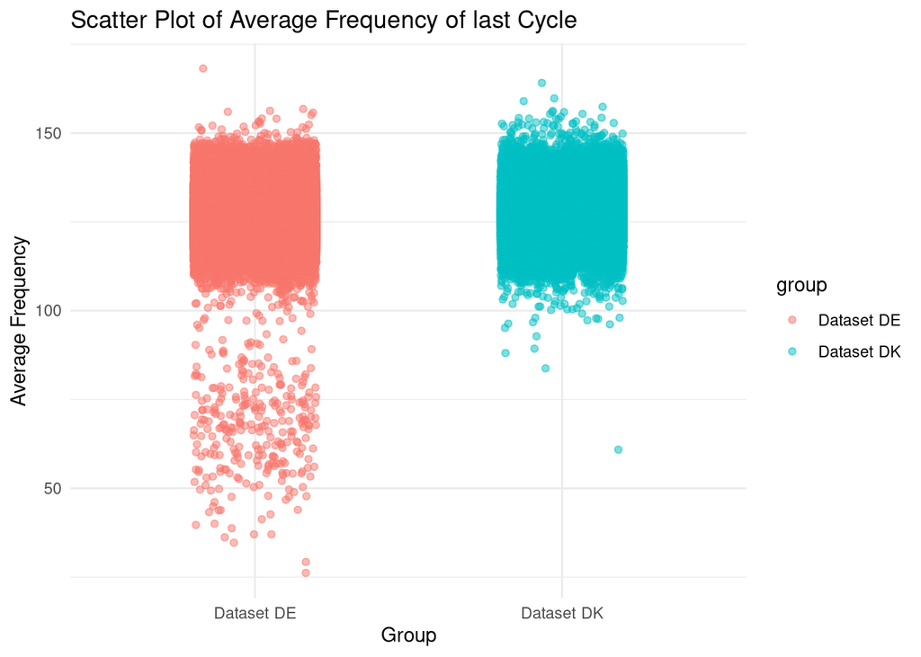

## Check Requirements for tests

### Normality of Distribution

Average end frequency DE:

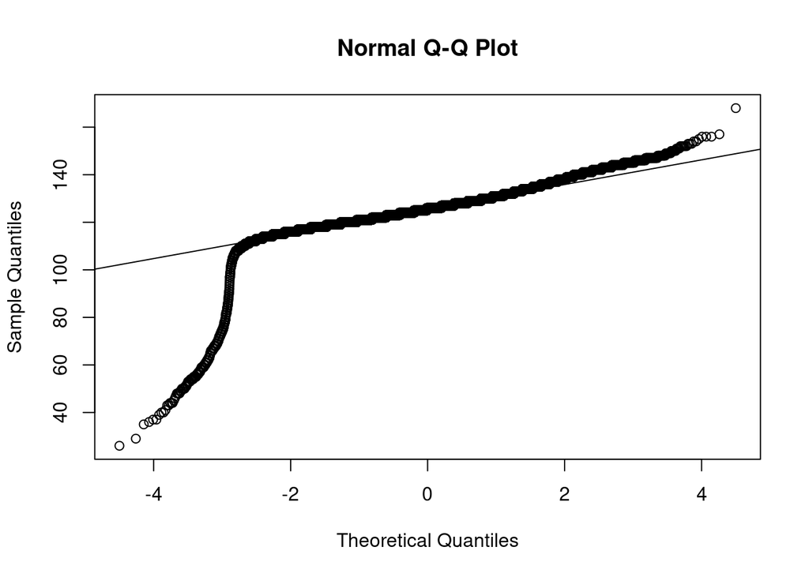

```
##
##  Asymptotic one-sample Kolmogorov-Smirnov test
##
## data:  Ref_DE$avEndF
## D = 0.076041, p-value < 2.2e-16
## alternative hypothesis: two-sided
```

Average end frequency DK:

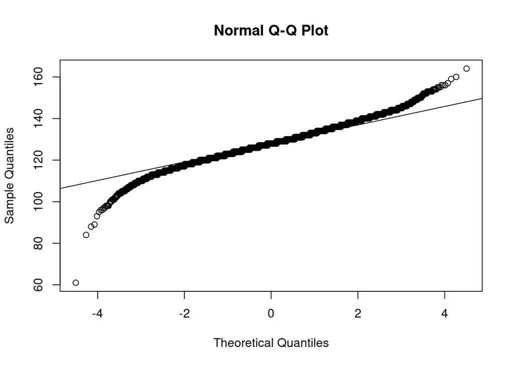

```
##
##  Asymptotic one-sample Kolmogorov-Smirnov test
##
## data:  Ref_DK$avEndF
## D = 0.056464, p-value < 2.2e-16
## alternative hypothesis: two-sided
```

No noticeable normal distribution in Q-Q-Plot which is underlined by the result of the Kolmogorov-Smirnov-Test.  
The small p-value (<2.2e-16) suggest that the distribution significantly differs from normal distribution.  
Also checking for homogeneity of variances (Levenes Test):

```
## Levene's Test for Homogeneity of Variance (center = median)
##           Df F value    Pr(>F)
## group      1  154.47 < 2.2e-16 ***
##       298231
## ---
## Signif. codes:  0 '***' 0.001 '**' 0.01 '*' 0.05 '.' 0.1 ' ' 1
```

p-value (<2.2e-16) < 0.05  
–> statistically significant difference in variances between the groups  
Meaning the null hypothesis of homogeneity of variances is rejected.

## Statistical Test

```
##
##  Wilcoxon rank sum test with continuity correction
##
## data:  Ref_DE$avEndF and Ref_DK$avEndF
## W = 8.396e+09, p-value < 2.2e-16
## alternative hypothesis: true location shift is not equal to 0
```

p (<2.2e-16) < 0.05  
–> there is a significant difference between the datasets for the average frequency of the last cycle

## Comparison of average sound Pressure Level

## Hypothesis

H_0: There is no difference in the distribution of the average sound pressure level between the german and danish harbour porpoise clicks

## Exploratory Analysis

```r
summary(Ref_DE$avSPL)
```

```
##    Min. 1st Qu.  Median    Mean 3rd Qu.    Max.
##   17.00   34.00   50.00   81.71   97.00  406.00
```

```r
summary(Ref_DK$avSPL)
```

```
##    Min. 1st Qu.  Median    Mean 3rd Qu.    Max.
##   17.00   34.00   58.00   94.65  125.00  406.00
```

Visualization/Plots:

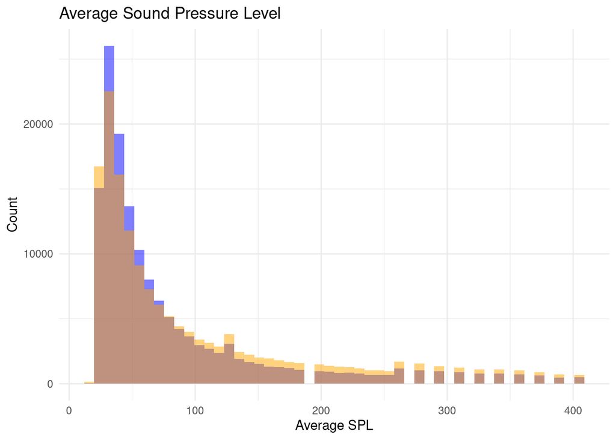

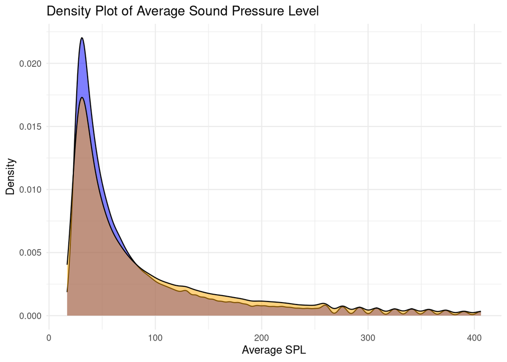

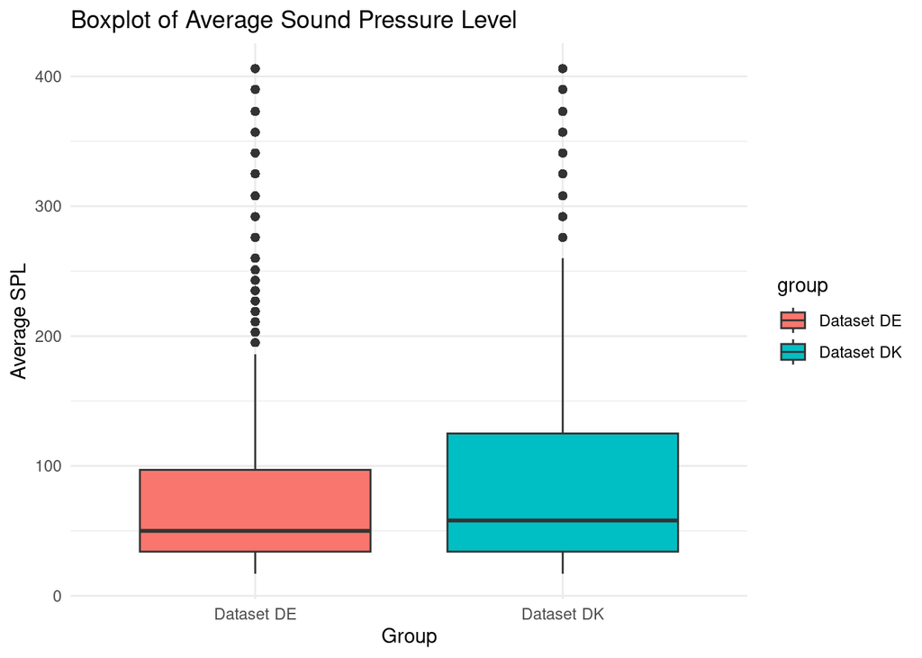

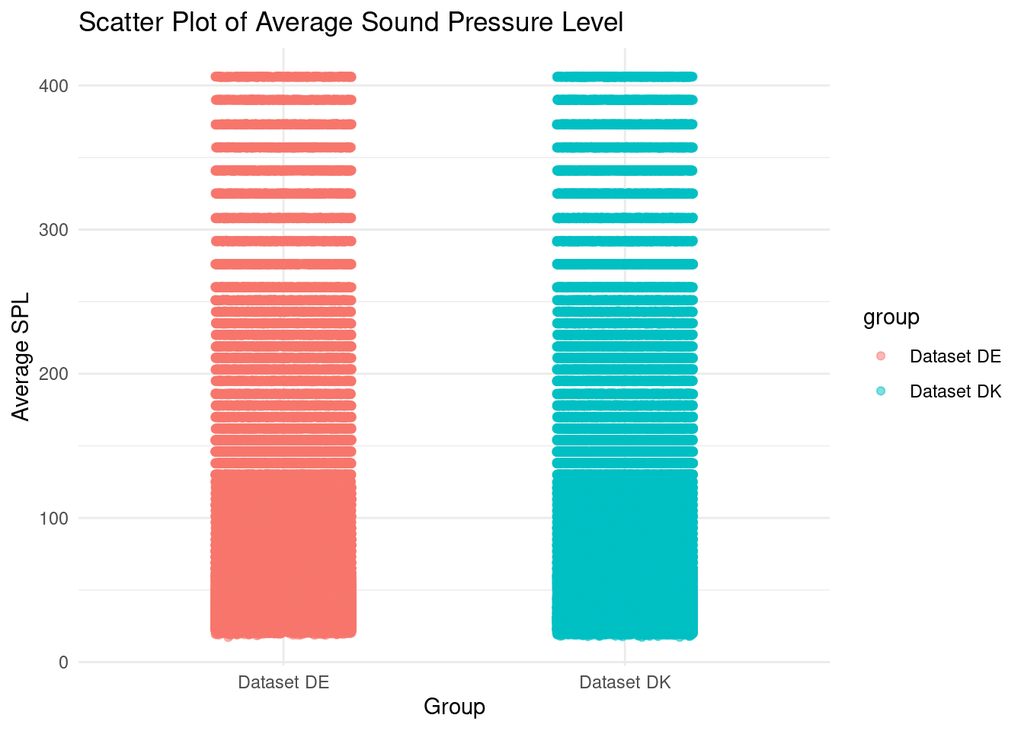

## Check Requirements

### Normality of Distribution

Average Sound Pressure Level DE:

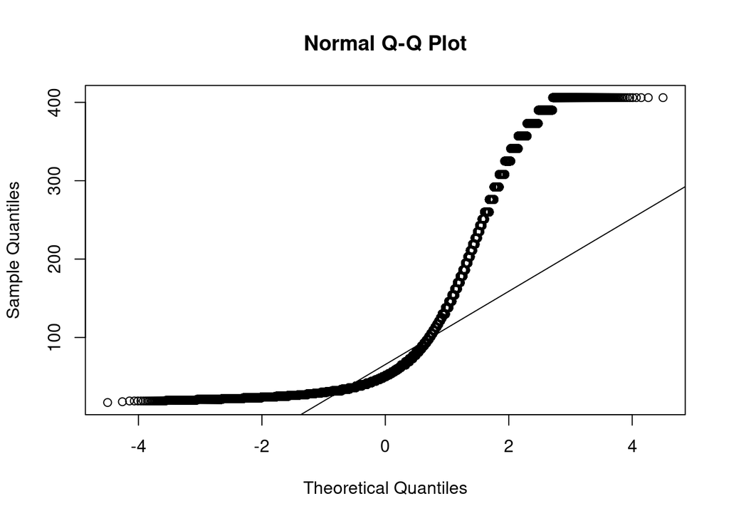

```
##
##  Asymptotic one-sample Kolmogorov-Smirnov test
##
## data:  Ref_DE$avSPL
## D = 0.21747, p-value < 2.2e-16
## alternative hypothesis: two-sided
```

Average Sound Pressure Level DK:

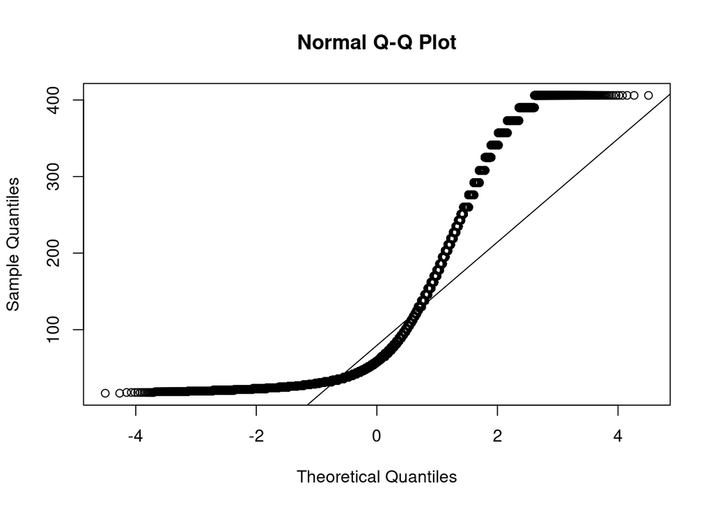

```
##
##  Asymptotic one-sample Kolmogorov-Smirnov test
##
## data:  Ref_DK$avSPL
## D = 0.19369, p-value < 2.2e-16
## alternative hypothesis: two-sided
```

No noticeable normal distribution in Q-Q-Plot which is underlined by the result of the Kolmogorov-Smirnov-Test.  
The small p-value (<2.2e-16) suggest that the distribution significantly differs from normal distribution.

Also checking for homogeneity of variances (Levenes Test):

```
## Levene's Test for Homogeneity of Variance (center = median)
##           Df F value    Pr(>F)
## group      1  1943.2 < 2.2e-16 ***
##       298231
## ---
## Signif. codes:  0 '***' 0.001 '**' 0.01 '*' 0.05 '.' 0.1 ' ' 1
```

p-value (<2.2e-16) < 0.05  
–> statistically significant difference in variances between the groups  
Meaning the null hypothesis of homogeneity of variances is rejected.

## Statistical Test

```
##
##  Wilcoxon rank sum test with continuity correction
##
## data:  Ref_DE$avSPL and Ref_DK$avSPL
## W = 1.0274e+10, p-value < 2.2e-16
## alternative hypothesis: true location shift is not equal to 0
```

p (<2.2e-16) < 0.05  
–> there is a significant difference between the datasets for the average sound pressure level  
Null Hypothesis rejected.

## Comparison of average Train Duration (micro seconds)

## Hypothesis

H_0: There is no difference in the distribution of the average Train Duration between the german and danish harbour porpoise clicks

## Exploratory Analysis

```r
summary(Ref_DE$TrDur_us)
```

```
##     Min.  1st Qu.   Median     Mean  3rd Qu.     Max.
##     7092   225806   437500   643913   800000 21000000
```

```r
summary(Ref_DK$TrDur_us)
```

```
##     Min.  1st Qu.   Median     Mean  3rd Qu.     Max.
##     4332   250000   487179   751134   937500 29000000
```

Visualization/Plots:

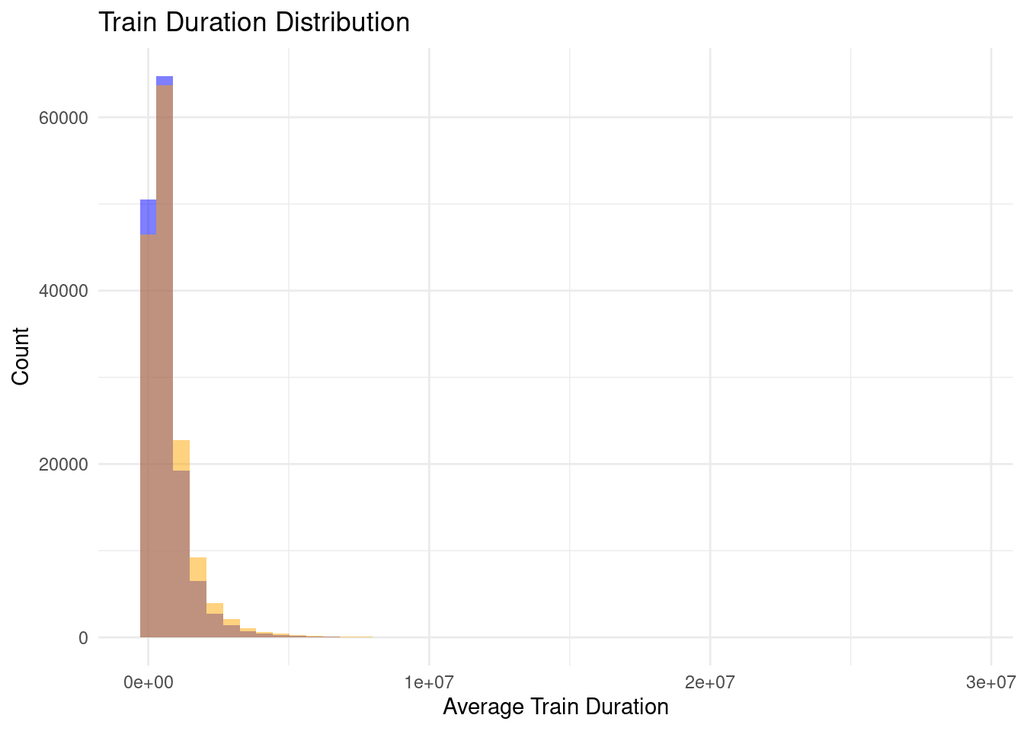

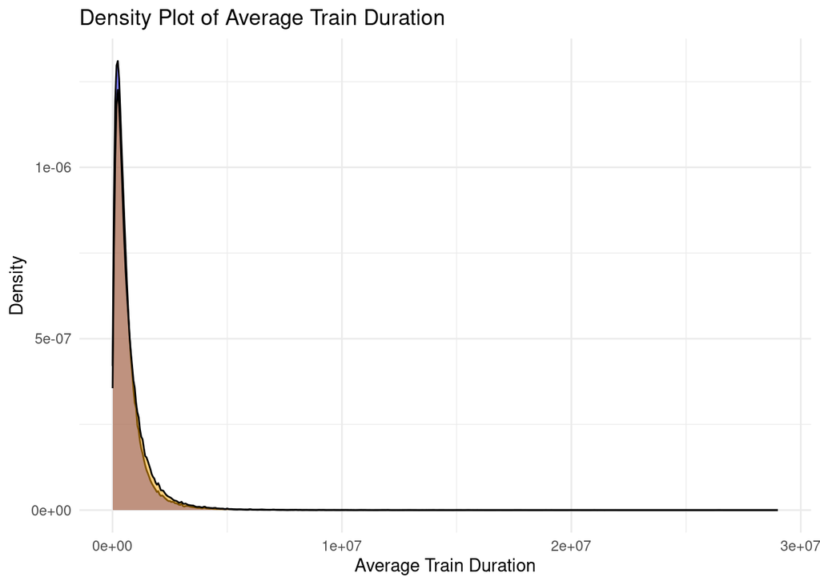

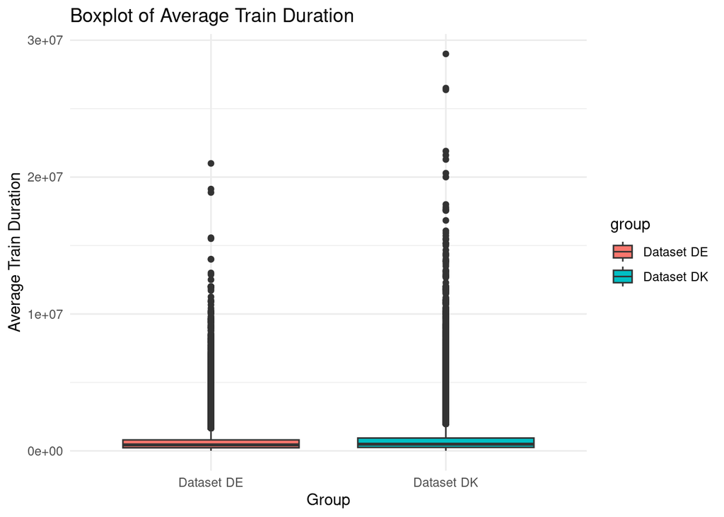

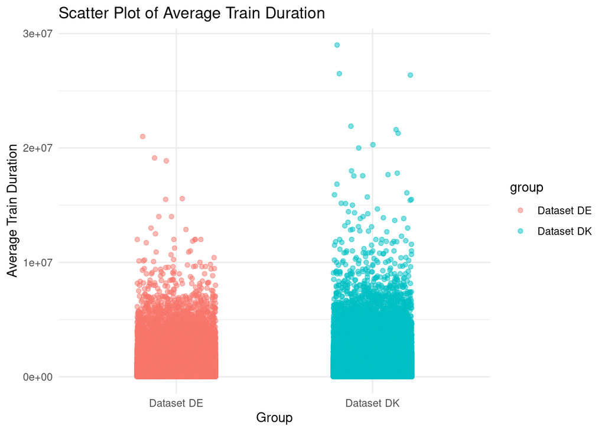

## Check Requirements

### Normality of Distribution

Train Duration DE:

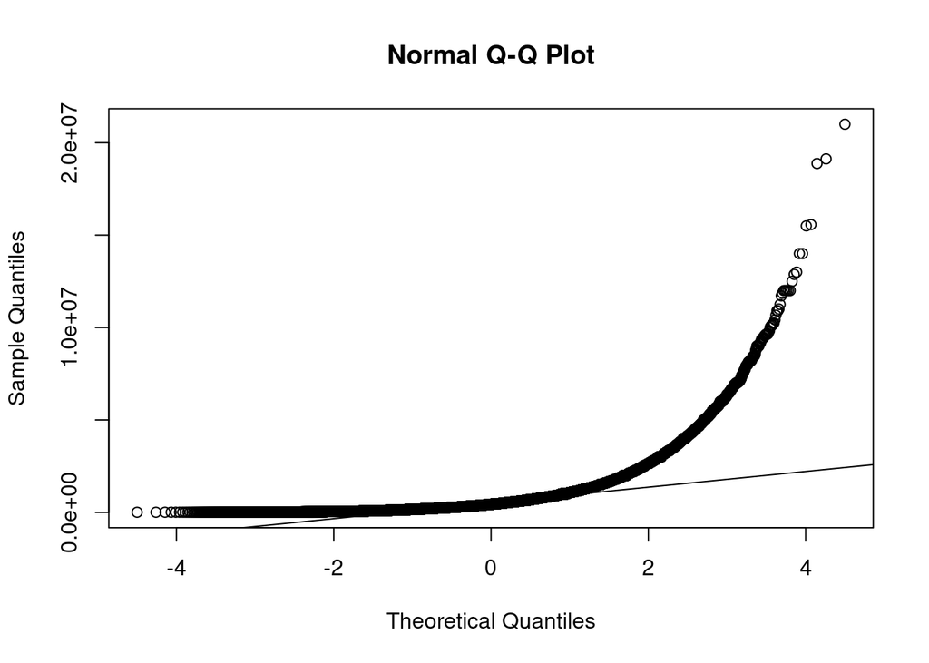

```
##
##  Asymptotic one-sample Kolmogorov-Smirnov test
##
## data:  Ref_DE$TrDur_us
## D = 0.19186, p-value < 2.2e-16
## alternative hypothesis: two-sided
```

Train Duration DK:

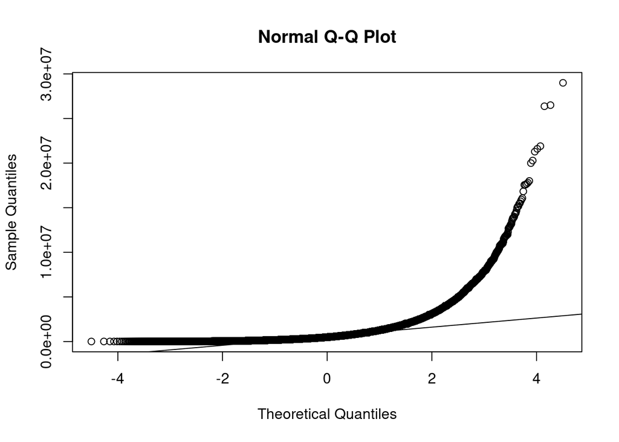

```
##
##  Asymptotic one-sample Kolmogorov-Smirnov test
##
## data:  Ref_DK$TrDur_us
## D = 0.20224, p-value < 2.2e-16
## alternative hypothesis: two-sided
```

No noticeable normal distribution in Q-Q-Plot which is underlined by the result of the Kolmogorov-Smirnov-Test.  
The small p-value (<2.2e-16) suggest that the distribution significantly differs from normal distribution.

Also checking for homogeneity of variances (Levenes Test):

```
## Levene's Test for Homogeneity of Variance (center = median)
##           Df F value    Pr(>F)
## group      1  1018.9 < 2.2e-16 ***
##       298231
## ---
## Signif. codes:  0 '***' 0.001 '**' 0.01 '*' 0.05 '.' 0.1 ' ' 1
```

p-value (<2.2e-16) < 0.05  
–> statistically significant difference in variances between the groups  
Meaning the null hypothesis of homogeneity of variances is rejected.

## Statistical Test

```
##
##  Wilcoxon rank sum test with continuity correction
##
## data:  Ref_DE$TrDur_us and Ref_DK$TrDur_us
## W = 1.0308e+10, p-value < 2.2e-16
## alternative hypothesis: true location shift is not equal to 0
```

p (<2.2e-16) < 0.05  
–> there is a significant difference between the datasets for the average Train Duration  
Null Hypothesis rejected.

### Statistical Tests, pairwise (Mann-Whitney)

```
##
##  Wilcoxon rank sum test with continuity correction
##
## data:  Ref_DE$MinICI_us and Ref_DE$medianKHz
## W = 2.1616e+10, p-value < 2.2e-16
## alternative hypothesis: true location shift is not equal to 0
```

```
##
##  Wilcoxon rank sum test with continuity correction
##
## data:  Ref_DE$MinICI_us and Ref_DE$NofClstrs
## W = 2.1616e+10, p-value < 2.2e-16
## alternative hypothesis: true location shift is not equal to 0
```

```
##
##  Wilcoxon rank sum test with continuity correction
##
## data:  Ref_DE$MinICI_us and Ref_DE$nActualClx
## W = 2.1616e+10, p-value < 2.2e-16
## alternative hypothesis: true location shift is not equal to 0
```

```
##
##  Wilcoxon rank sum test with continuity correction
##
## data:  Ref_DE$MinICI_us and Ref_DE$AvPRF
## W = 2.1583e+10, p-value < 2.2e-16
## alternative hypothesis: true location shift is not equal to 0
```

```
##
##  Wilcoxon rank sum test with continuity correction
##
## data:  Ref_DE$NofClstrs and Ref_DE$medianKHz
## W = 162749319, p-value < 2.2e-16
## alternative hypothesis: true location shift is not equal to 0
```

```
##
##  Wilcoxon rank sum test with continuity correction
##
## data:  Ref_DE$nActualClx and Ref_DE$medianKHz
## W = 162749319, p-value < 2.2e-16
## alternative hypothesis: true location shift is not equal to 0
```

```
##
##  Wilcoxon rank sum test with continuity correction
##
## data:  Ref_DE$AvPRF and Ref_DE$medianKHz
## W = 2814591118, p-value < 2.2e-16
## alternative hypothesis: true location shift is not equal to 0
```

```
##
##  Wilcoxon rank sum test with continuity correction
##
## data:  Ref_DE$NofClstrs and Ref_DE$nActualClx
## W = 1.0808e+10, p-value = 1
## alternative hypothesis: true location shift is not equal to 0
```

```
##
##  Wilcoxon rank sum test with continuity correction
##
## data:  Ref_DE$NofClstrs and Ref_DE$AvPRF
## W = 4932252295, p-value < 2.2e-16
## alternative hypothesis: true location shift is not equal to 0
```

```
##
##  Wilcoxon rank sum test with continuity correction
##
## data:  Ref_DE$nActualClx and Ref_DE$AvPRF
## W = 4932252295, p-value < 2.2e-16
## alternative hypothesis: true location shift is not equal to 0
```

```
##
##  Wilcoxon rank sum test with continuity correction
##
## data:  Ref_DK$MinICI_us and Ref_DK$medianKHz
## W = 2.2863e+10, p-value < 2.2e-16
## alternative hypothesis: true location shift is not equal to 0
```

```
##
##  Wilcoxon rank sum test with continuity correction
##
## data:  Ref_DK$MinICI_us and Ref_DK$NofClstrs
## W = 2.2863e+10, p-value < 2.2e-16
## alternative hypothesis: true location shift is not equal to 0
```

```
##
##  Wilcoxon rank sum test with continuity correction
##
## data:  Ref_DK$MinICI_us and Ref_DK$nActualClx
## W = 2.2863e+10, p-value < 2.2e-16
## alternative hypothesis: true location shift is not equal to 0
```

```
##
##  Wilcoxon rank sum test with continuity correction
##
## data:  Ref_DK$MinICI_us and Ref_DK$AvPRF
## W = 2.2823e+10, p-value < 2.2e-16
## alternative hypothesis: true location shift is not equal to 0
```

```
##
##  Wilcoxon rank sum test with continuity correction
##
## data:  Ref_DK$NofClstrs and Ref_DK$medianKHz
## W = 255849719, p-value < 2.2e-16
## alternative hypothesis: true location shift is not equal to 0
```

```
##
##  Wilcoxon rank sum test with continuity correction
##
## data:  Ref_DK$nActualClx and Ref_DK$medianKHz
## W = 255849719, p-value < 2.2e-16
## alternative hypothesis: true location shift is not equal to 0
```

```
##
##  Wilcoxon rank sum test with continuity correction
##
## data:  Ref_DK$AvPRF and Ref_DK$medianKHz
## W = 2400410650, p-value < 2.2e-16
## alternative hypothesis: true location shift is not equal to 0
```

```
##
##  Wilcoxon rank sum test with continuity correction
##
## data:  Ref_DK$NofClstrs and Ref_DK$nActualClx
## W = 1.1432e+10, p-value = 1
## alternative hypothesis: true location shift is not equal to 0
```

```
##
##  Wilcoxon rank sum test with continuity correction
##
## data:  Ref_DK$NofClstrs and Ref_DK$AvPRF
## W = 6142140734, p-value < 2.2e-16
## alternative hypothesis: true location shift is not equal to 0
```

```
##
##  Wilcoxon rank sum test with continuity correction
##
## data:  Ref_DK$nActualClx and Ref_DK$AvPRF
## W = 6142140734, p-value < 2.2e-16
## alternative hypothesis: true location shift is not equal to 0
```

### Correlations

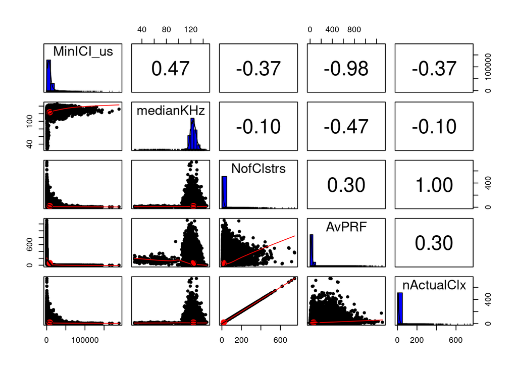

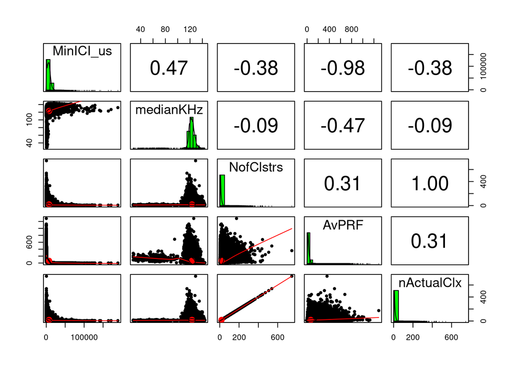

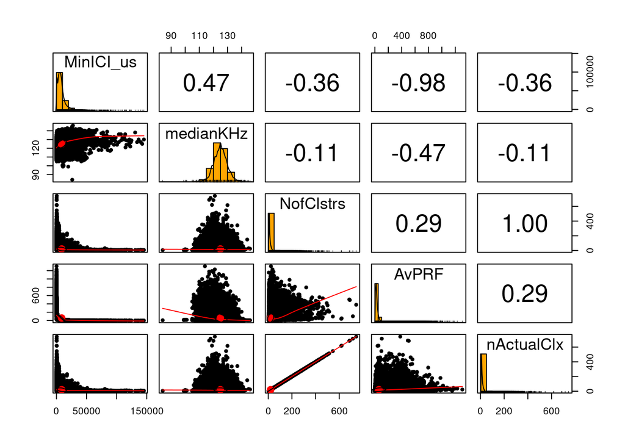

## Histogram of DE Ref Stations

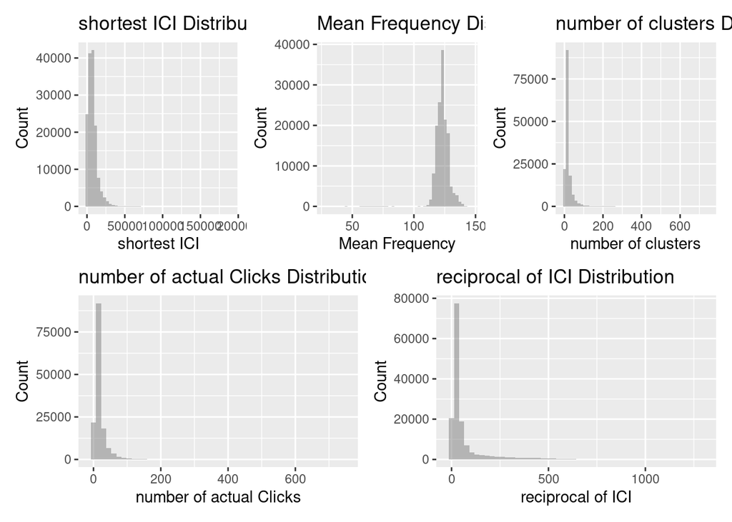